# FiveThirtyEight COVID-19 Approval Tracker

Jeff Parks

2021-08-29

## Introduction

FiveThirtyEight publishes a [daily tracker](https://projects.fivethirtyeight.com/coronavirus-polls/) measuring public approval of the President’s handling of the COVID-19 pandemic.

Their approach aggregates all available, scientifically-valid surveys from the field, and weights the results from each pollster using a [custom rating formula](https://projects.fivethirtyeight.com/pollster-ratings/) that factors in historical accuracy, adherence to industry best practices, and reliance on landline responses.

## Observations

This quick overview uses the **covid_approval_polls_adjusted** [dataset](https://github.com/fivethirtyeight/covid-19-polls) updated on August 25, 2021. The dataset contains results from 783 distinct surveys from 54 polling firms, beginning February 2, 2020 and ending August 24, 2021.

The survey questions vary slightly among pollsters, but roughly condense to “Do you approve or disapprove of the President’s handling of the coronavirus outbreak? (Yes/No)”

Breakdowns of respondents include political party affiliation (Democratic, Republican, Independent) and voter registration status (Unregistered Adult, Registered Voter, Likely Voter)

This dataset informs one of the main findings in the [FiveThirtyEight Coronavirus Polls](https://projects.fivethirtyeight.com/coronavirus-polls/%7D) tracker, with the finding **“Approval of Biden’s response varies widely by party.”**

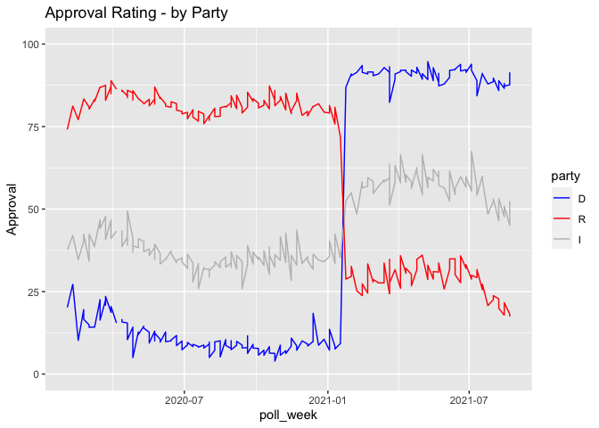

While this conclusion is not at all surprising given our political climate, some additional questions come to mind that might be worth exploring:

**What does the overall picture look like, without party identification?**

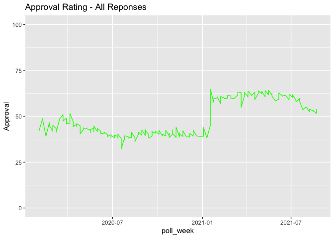

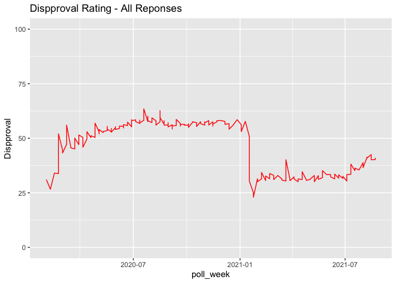

In the aggregate, voters have shifted decisively in favor of the new administration’s handling of the COVID-19 pandemic .. so far.

**Has political polarization on this issue increased or decreased between administrations, and what is its general direction now?**

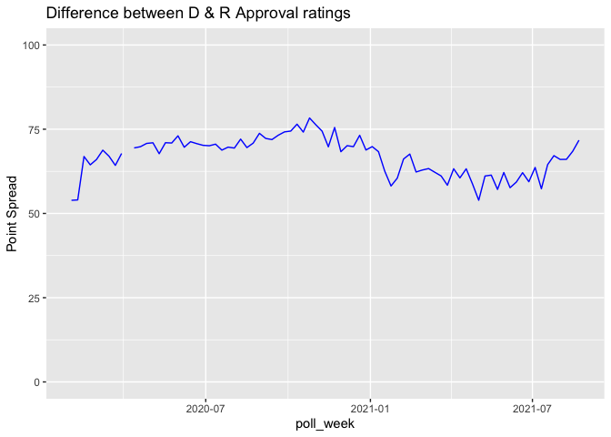

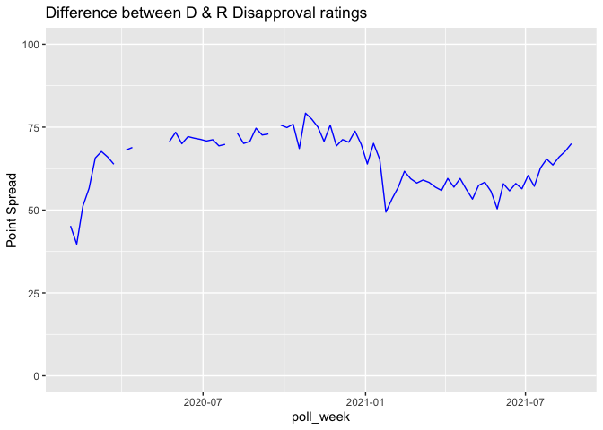

**Are there significant deviations from this trend between Registered and Unregistered voters? Between Likely and Unlikely voters?**

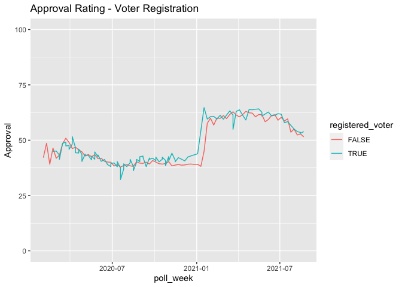

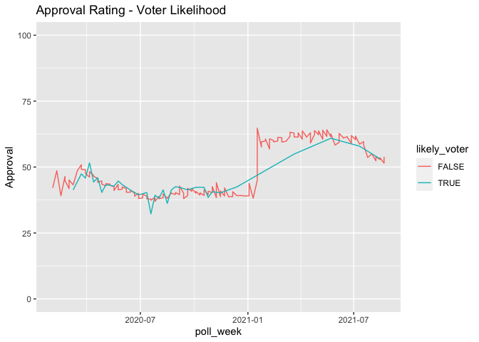

Surprisingly, neither voter registration nor “likely voter” status seemed have an impact on approval ratings.

## Conclusion

FiveThirtyEight’s approach to poll analysis is fascinating. By acknowledging the biases inherent in different methodologies, capabilities and ideological viewpoints between pollsters, they have built a fairly robust and even-handed model for predicting the outcomes of political contests.